# Små elbiler — vægtet pointmodel

Billige, fabriksnye små elbiler

20 August 2026

## Sådan virker modellen

Søster-rapport til de små **brændstofbiler** — samme vægtede pointmodel og samme tre prioriteter, men feltet er billige, fabriksnye **små elbiler** (A/B-segment), alle med automatgear (el = automat).

**Need-to-have krav (adgangsbillet, ikke point).** En bil skal opfylde *alle* tre for at komme med i tabellen — de er ufravigelige, så de fungerer som filter frem for som scorede parametre (derfor står de som `info`-rækker, hvor alle biler har samme værdi):

1. **Varmepumpe** — standard eller tilkøbeligt
2. **Forkonditionering af batteri**
3. **5 døre**

**Prioriteter** (vægt 3 → 1):

1. **Samlet økonomi** (vægt 3) — totaløkonomi: *anskaffelse* + *4-års værditab* + *4-års energi* (kr)
2. **Driftsikkerhed** (vægt 2) — nybilsgaranti i år
3. **Personsikkerhed** (vægt 1) — Euro NCAP-stjerner

Modellens mekanik er identisk med de andre rapporter:

1. **Data** ligger i smaa_elbiler_specs.csv — én række pr. parameter, én kolonne pr. bil.
2. Hver parameter har en **`kategori`** (eller `info`) og en **`retning`** (`hoej`/`lav`). For elbiler er økonomi-forbruget Wh/km, hvor **lavere er bedst**.
3. **Ratio-normalisering** pr. parameter (bedste bil = 1,0).
4. **Robust over for huller** (en parameter scorer ved ≥2 biler; indeks renormaliseres med vægten af de kategorier bilen har data for).
5. **Slutindeks** = vægtet gennemsnit, skaleret 0–100.

## Specifikationer (rådata)

Vandret scroll viser alle biler. `—` = ukendt/ikke udfyldt.

| Parameter | Enhed | MG4 | Hyundai_Inster | Nissan_Micra | Renault_5 | Renault_4 | Kia_EV2 | VW_ID_Polo | Hyundai_Kona_E | Suzuki_e_Vitara | Toyota_Urban_Cruiser | Kategori |
| --- | --- | --- | --- | --- | --- | --- | --- | --- | --- | --- | --- | --- |
| Pris | kr | 174.999 | 181.990 | 189.900 | 189.990 | 199.990 | 199.999 | 212.990 | 219.995 | 229.990 | 234.990 | oekonomi |
| Maerke | navn | MG | Hyundai | Nissan | Renault | Renault | Kia | VW | Hyundai | Suzuki | Toyota | info |
| Varmepumpe | ja=1 | 1 | 1 | 1 | 1 | 1 | 1 | 1 | 1 | 1 | 1 | info |
| Forkonditionering | ja=1 | 1 | 1 | 1 | 1 | 1 | 1 | 1 | 1 | 1 | 1 | info |
| Doere | antal | 5 | 5 | 5 | 5 | 5 | 5 | 5 | 5 | 5 | 5 | info |
| Energiforbrug | Wh/km | 164 | 153 | 154 | 154 | 163 | 171 | 153 | 165 | 177 | 177 | info |
| Raekkevidde | km | 290 | 320 | 310 | 312 | 300 | 317 | 328 | 377 | 344 | 344 | info |
| Batteri_kWh | kWh | 41,9 | 42 | 40 | 40 | 40 | 42,2 | 37 | 48,6 | 49 | 48,8 | info |
| Bagagerum | liter | 480 | 280 | 326 | 326 | 420 | 362 | 441 | 466 | 238 | 238 | info |
| Effekt_hk | hk | 170 | 97 | 122 | 120 | 120 | — | 135 | 156 | 144 | 144 | info |
| Garanti_bil_aar | aar | 7 | 5 | 5 | 5 | 5 | 7 | 5 | 5 | 6 | 10 | driftsikkerhed |
| Garanti_km | km | 150.000 | ubegrænset | 100.000 | 150.000 | 150.000 | 150.000 | 150.000 | ubegrænset | 150.000 | 185.000 | info |
| Garanti_batteri_aar | aar | 8 | 8 | 8 | 8 | 8 | 8 | 8 | 8 | 8 | 8 | info |
| NCAP_stjerner | stjerner | 5 | 4 | 4 | 4 | 4 | — | — | 4 | — | — | personsikkerhed |
| NCAP_adult | pct | 87 | 70 | — | 80 | — | — | — | — | — | — | info |
| NCAP_child | pct | 85 | 81 | — | 80 | — | — | — | — | — | — | info |
| NCAP_vru | pct | 85 | 70 | — | 76 | — | — | — | — | — | — | info |
| NCAP_safety_assist | pct | 80 | 67 | — | 68 | — | — | — | — | — | — | info |
| Vaerditab_pct_aar | pct | — | 10 | 13,5 | 13,7 | 13,7 | 12,1 | 18,3 | 10 | — | 6,8 | info |
| Vaerditab_4aar | kr | — | 62.586 | 83.586 | 84.606 | 89.059 | 80.605 | 118.094 | 75.656 | — | 57.688 | oekonomi |
| Drift_4aar | kr | 27.060 | 25.245 | 25.410 | 25.410 | 26.895 | 28.215 | 25.245 | 27.225 | 29.205 | 29.205 | oekonomi |

## Prioriteter og vægte

| Prioritet | Kategori | Vægt | Har data |
| --- | --- | --- | --- |
| 1 | Samlet økonomi | 3 | ja |
| 2 | Driftsikkerhed | 2 | ja |
| 3 | Personsikkerhed | 1 | ja |

## Kategoriscorer (0–100)

| Kategori | Vægt | MG4 | Hyundai_Inster | Nissan_Micra | Renault_5 | Renault_4 | Kia_EV2 | VW_ID_Polo | Hyundai_Kona_E | Suzuki_e_Vitara | Toyota_Urban_Cruiser |
| --- | --- | --- | --- | --- | --- | --- | --- | --- | --- | --- | --- |
| Samlet økonomi | 3 | 97 | 96 | 87 | 87 | 82 | 83 | 77 | 83 | 81 | 87 |
| Driftsikkerhed | 2 | 70 | 50 | 50 | 50 | 50 | 70 | 50 | 50 | 60 | 100 |
| Personsikkerhed | 1 | 100 | 80 | 80 | 80 | 80 | — | — | 80 | — | — |

## Slutresultat

| Placering | Bil | Indeks | Datadækning |
| --- | --- | --- | --- |
| 1 | Toyota_Urban_Cruiser† | 92,2 | 2/3 |
| 2 | MG4 | 88,3 | 3/3 |
| 3 | Hyundai_Inster | 78,1 | 3/3 |
| 4 | Kia_EV2† | 77,7 | 2/3 |
| 5 | Nissan_Micra | 73,4 | 3/3 |
| 6 | Renault_5 | 73,3 | 3/3 |
| 7 | Suzuki_e_Vitara† | 72,8 | 2/3 |
| 8 | Hyundai_Kona_E | 71,4 | 3/3 |
| 9 | Renault_4 | 71 | 3/3 |
| 10 | VW_ID_Polo† | 66,2 | 2/3 |

*Datadækning* = antal vægtede kategorier bilen har data for (her højst 3).

† **Fodnote (Euro NCAP):** Kia EV2, VW ID Polo, Suzuki e Vitara, Toyota Urban Cruiser er endnu ikke Euro NCAP-testede og scorer derfor *ikke* på personsikkerhed (datadækning 2/3). Da manglende data ikke straffes, løfter det dem relativt i indekset — de kan falde, når testresultater foreligger.

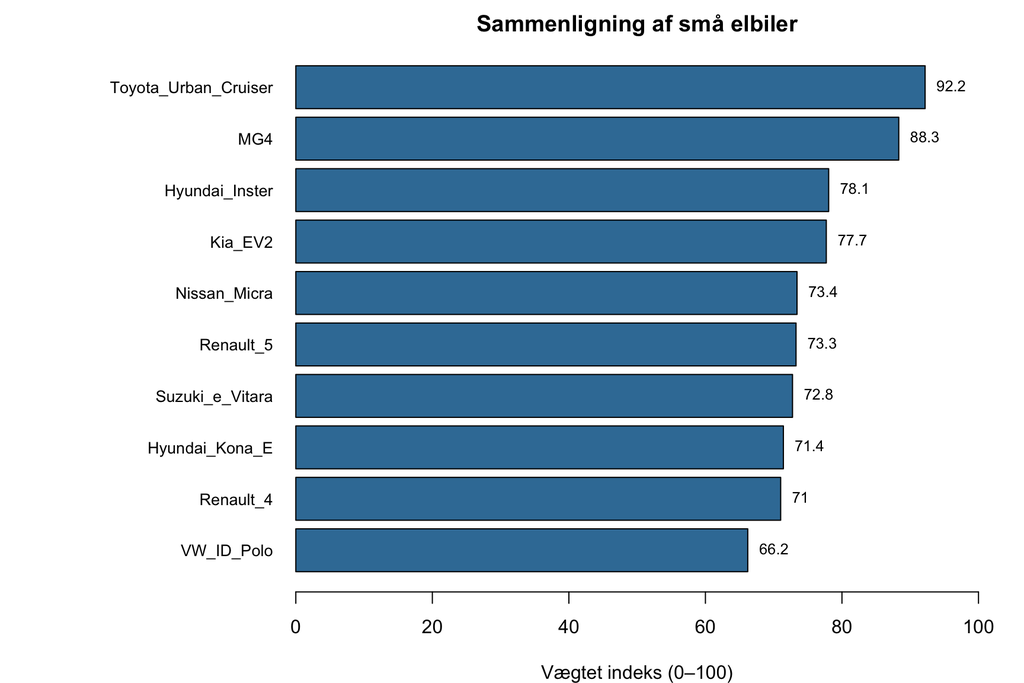

## Hvem vinder hver kategori

| Kategori | Vægt | Vinder |
| --- | --- | --- |
| Samlet økonomi | 3 | MG4 |
| Driftsikkerhed | 2 | Toyota_Urban_Cruiser |
| Personsikkerhed | 1 | MG4 |

## Sådan opdaterer du

- **Ny værdi:** ret tallet i smaa_elbiler_specs.csv og knit igen.
- **Ny bil:** tilføj en kolonne i smaa_elbiler_specs.csv med bilens navn og værdier.
- **Ny parameter:** tilføj en række; sæt `kategori` (eller `info`) og `retning`.
- **Anden vægtning:** ret `vaegt` i smaa_elbiler_vaegte.csv.

Knit fra R: `rmarkdown::render("smaa_elbiler.Rmd")`.

## Datagrundlag og forbehold

**Krav til feltet:** fabriksnye små elbiler (A/B-segment), automatgear, billig anskaffelse — samt de tre need-to-have krav: **varmepumpe**, **forkonditionering af batteri** og **5 døre**.

**Valgt variant pr. bil** = den billigste, der opfylder alle tre krav. To biler kræver tilkøb/højere trim for at komme i mål, og prisen er justeret derefter:

| Bil | Variant | Note til prisen |
| --- | --- | --- |
| Hyundai Inster | Essential + Vinterpakke | 174.995 + 6.995 (varmepumpe + batterivarmer) |
| VW ID. Polo | Life 37 kWh + varmepumpe | 204.995 + 7.995 (basis *Trend* har den ikke) |

**Udelukket af de tre krav** (var med i tidligere version):

| Bil | Årsag |
| --- | --- |
| Citroën ë-C3 · ë-C3 Aircross | Ingen varmepumpe — findes ikke, heller ikke som tilkøb |
| Fiat Grande Panda · Opel Frontera | Samme Stellantis *Smart Car*-platform, ingen varmepumpe |
| BYD Dolphin Surf | Ingen varmepumpe, kan ikke tilkøbes |
| Dacia Spring · Leapmotor T03 | Ingen varmepumpe/forkonditionering (budget-mikrobiler) |
| Fiat 500e | Kun 3-dørs (3+1 har blot en lille halv bagdør) |
| Peugeot e-208 · Opel Corsa Electric | Varmepumpe ja, men e-CMP-platformen har ikke reel batteri-forkonditionering (Stellantis har først indført det på de nyere STLA-modeller) |

**Kandidater der endnu ikke er med:** Škoda Epiq, Cupra Raval og Volvo EX30 opfylder formentlig kravene, men er så nye, at pris/udstyr/NCAP ikke kunne verificeres tilstrækkeligt — og de billigste varianter ligger over feltets prisniveau (Epiq reelt fra 244.995, EX30 kræver Extended Range for varmepumpe).

**Scorede parametre:** *Økonomi* = **totaløkonomi (TCO)** med tre lige-vægtede lav-parametre: anskaffelsespris + 4-års værditab (kr) + 4-års energi (kr). *Driftsikkerhed* = nybilsgaranti i år (høj). *Personsikkerhed* = Euro NCAP-stjerner (høj). Øvrige rækker (energiforbrug, rækkevidde, batteri, effekt, bagagerum, NCAP-delscorer, garanti-km/-batteri, mærke, værditab-%) er `info`.

**Værditab (TCO).** `Vaerditab_4aar = Pris × (1−(1−r)⁴)`, hvor `r` er mærkets **el-specifikke, mileage-justerede** afskrivning/år fra `depreciation_by_fueltype.csv` (genereret af `depreciation_by_fueltype.R` fra bilbasen-data — `analyze_depreciation.Rmd` er urørt). Raterne er empirisk-Bayes-krympet efter regressionens standardfejl, så usikre mærke-estimater trækkes mod gennemsnittet. Energiudgift = 60.000 km × Wh/km × 2,75 kr/kWh. Antagelser (4 år, 15.000 km/år, elpris) ændres i `tco`-chunken. **MG og Suzuki** mangler el-brugtmarked → værditab `—` (scorer kun på pris+energi). EV-afskrivning hviler på et kortere, mere usikkert brugtmarked end benzin.

**Kilder.** Tekniske specs (forbrug Wh/km, rækkevidde WLTP, batteri, effekt, bagagerum) fra [EV-Database](https://ev-database.org); priser/garanti fra danske importørsider; NCAP fra [Euro NCAP](https://www.euroncap.com).

**Forbehold:**